# CKME136 Capstone - Cleaning and Exploratory Analysis of Diabetes Readmission Data

### Ordinal Variable by Readmission Status

For the one remaining ordinal variable, age, the frequencies and histograms of each group will be reviewed, and a wilcoxon rank sum test will be completed to identify if there is a statistically significant difference between the two groups.

**Age VS Readmitted**

```r
table(db.expl$age, db.expl$readmitted) # Values appear to peak similarly in the 70-80 range
```

```
##
##              <30 Not<30
##   [0-10)       3    150
##   [10-20)     26    508
##   [20-30)     83   1038
##   [30-40)    188   2504
##   [40-50)    506   6322
##   [50-60)    879  11470
##   [60-70)   1412  14272
##   [70-80)   1817  15933
##   [80-90)   1195   9907
##   [90-100)   168   1592
```

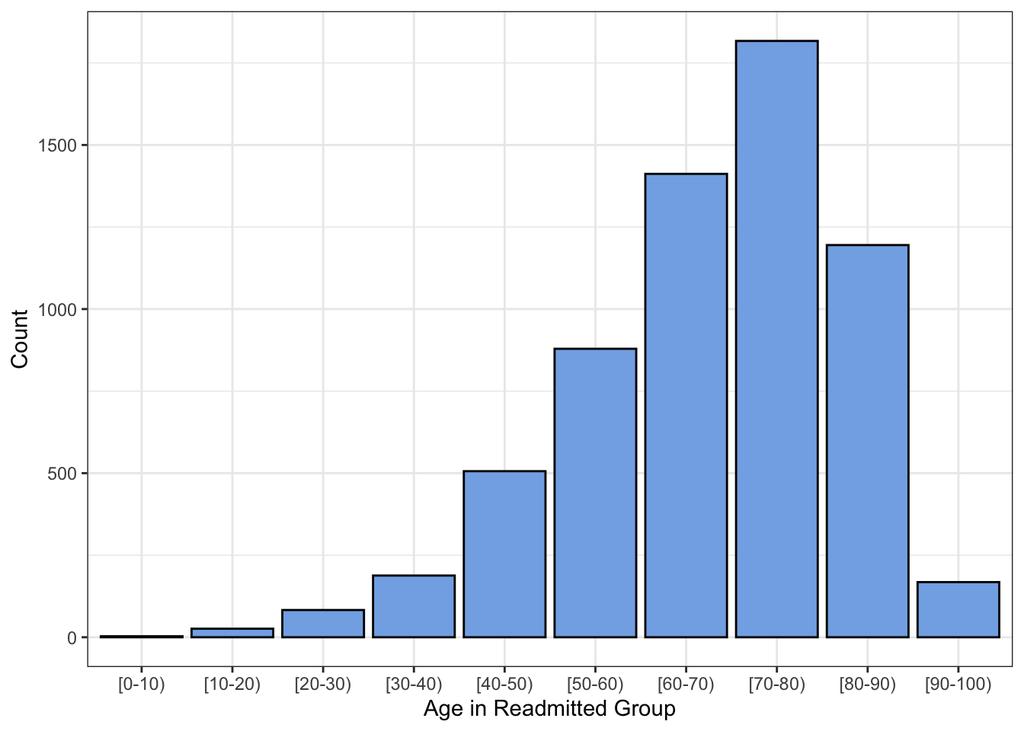

```r
ggplot(subset(db.expl, db.expl$readmitted == "<30"), aes(age)) + geom_bar(color = 'black', fill = '#83afe6') + theme_bw() + labs(x = 'Age in Readmitted Group', y = 'Count')
```

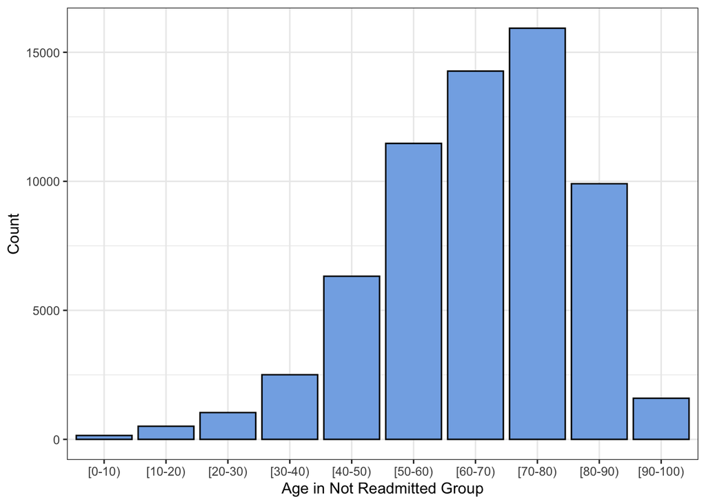

```r
ggplot(subset(db.expl, db.expl$readmitted == "Not<30"), aes(age)) + geom_bar(color = 'black', fill = '#83afe6') + theme_bw() + labs(x = 'Age in Not Readmitted Group', y = 'Count') # The distribution of the readmitted in <30 days group appears to have a bit more weight to the right than the other group
```

```r
age.numeric <- as.numeric(db.expl$age) # Convert Age to its ordered IDs (1-10) so that it may be used with the wilcoxon rank sum test function
wilcox.test(age.numeric~db.expl$readmitted, alternative = 'greater', paired = F) # Findings are highly significant (p<2.2e-16) that the center of the <30 group is greater than the center of the Not<30 group. Therefore, patients who have been readmitted within 30 days are generally older
```

```
##
##  Wilcoxon rank sum test with continuity correction
##
## data:  age.numeric by db.expl$readmitted
## W = 219034815, p-value < 2.2e-16
## alternative hypothesis: true location shift is greater than 0
```

### Categorical Variables by Readmission Status

First we will define a custom function to be used to calculate the percent contribution of each cell of a table to the chi-squared test statistic to identify combinations of categories with the highest contributions.

```r
percent_contrib <- function(x) {
  y <- 100*x$residuals^2/x$statistic
  return(round(y, 3))
}
```

For each categorical variable, we will review the frequencies for each readmission group, complete a chi-squared test to identify if the groups have a statistically significant difference, and then, if the findings are statistically significant, review the percent contribution and residuals of cells to identify associations between categories of the variables.

**Race VS Readmitted**

```r
table(db.expl$race, db.expl$readmitted)
```

```
##
##                     <30 Not<30
##   Caucasian        4942  49268
##   AfricanAmerican  1093  11532
##   Asian              41    447
##   Hispanic          122   1378
##   Other              79   1071
```

```r
race_readm.chisq <- chisq.test(table(db.expl$race, db.expl$readmitted))
race_readm.chisq # The results are statistically significant at the alpha = 0.05 level (p=0.0311), indicating that there is a statistically significant association between the two variables (i.e., they are not independent)
```

```
##
##  Pearson's Chi-squared test
##
## data:  table(db.expl$race, db.expl$readmitted)
## X-squared = 10.625, df = 4, p-value = 0.03111
```

```r
percent_contrib(race_readm.chisq) # The percent contribution (100*residual^2/chi-squared) indicates that the number of patients who identified their race as "Other" and were readmitted within 30 days contributed most to the total chi-square score (53.3%). Caucasian (12.1%), African American (13.0%), and Hispanic (11.0%) with <30 each contributed similarly.
```

```
##
##                      <30 Not<30
##   Caucasian       12.089  1.191
##   AfricanAmerican 12.991  1.280
##   Asian            1.657  0.163
##   Hispanic        11.032  1.087
##   Other           53.260  5.249
```

```r
round(race_readm.chisq$residuals,2) # We can see that since the residual is negative for the Other, <30 cell, there were fewer people observed than expected, indicating a negative association. Otherwise, we can see from the residuals that there was a positive association for Caucasian and <30, and a negative association for Aftrican American and Hispanic with <30. I.e., more Caucasian patients were readmitted within 30 days than expected, and fewer African American, Hispanic, and "Other" patients were. This could make sense given that in the U.S., ethnic minorities are more likely to be of a lower socioeconomic status, and therefore are less likely to have health insurance and feel comfortable seeking care
```

```
##
##                     <30 Not<30
##   Caucasian        1.13  -0.36
##   AfricanAmerican -1.17   0.37
##   Asian           -0.42   0.13
##   Hispanic        -1.08   0.34
##   Other           -2.38   0.75
```

**Gender VS Readmitted**

```r
table(db.expl$gender, db.expl$readmitted)
```

```
##
##            <30 Not<30
##   Female  3361  33871
##   Male    2916  29825
```

```r
chisq.test(table(db.expl$gender, db.expl$readmitted)) # The chi-squared test is not statistically significant (p=0.5856), indicating that we cannot reject the null hypothesis that the two variables are independent
```

```
##
##  Pearson's Chi-squared test with Yates' continuity correction
##
## data:  table(db.expl$gender, db.expl$readmitted)
## X-squared = 0.29729, df = 1, p-value = 0.5856
```

**Admission Type ID VS Readmitted**

```r
table(db.expl$admission_type_id, db.expl$readmitted)
```

```
##
##               <30 Not<30
##   Emergency  3987  39372
##   Urgent     1148  11654
##   Elective   1141  12644
##   Other         1     26
```

```r
admtype_readm.chisq <- chisq.test(table(db.expl$admission_type_id, db.expl$readmitted))
admtype_readm.chisq # The results are highly significant (p=0.008417), indicating that there is an association between the two variables
```

```
##
##  Pearson's Chi-squared test
##
## data:  table(db.expl$admission_type_id, db.expl$readmitted)
## X-squared = 11.717, df = 3, p-value = 0.008417
```

```r
percent_contrib(admtype_readm.chisq) # The percent contribution indicates that the number of patients who were readmitted within 30 days for elective reasons contributed the most (63.1%), with those readmitted within 30 days through emergency contributing the next most (20.8%)
```

```
##
##                <30 Not<30
##   Emergency 20.831  2.053
##   Urgent     0.001  0.000
##   Elective  63.072  6.215
##   Other      7.126  0.702
```

```r
round(admtype_readm.chisq$residuals,2) # The residual is negative for <30, Elective, indicating that the number seen is less than expected. The residual is positive for <30, Emergency, indicating more people were admitted through emergency than expected. These findings suggest that if you are admitted to hospital for planned reasons, you are less likely to be readmitted within 30 days
```

```
##
##               <30 Not<30
##   Emergency  1.56  -0.49
##   Urgent    -0.01   0.00
##   Elective  -2.72   0.85
##   Other     -0.91   0.29
```

**Discharge Disposition ID VS Readmitted**

```r
table(db.expl$discharge_disposition_id, db.expl$readmitted)
```

```
##
##                           <30 Not<30
##   DcHome                 3377  44192
##   DcOtherFacility         868   3919
##   DcSNF                  1176   7608
##   DcHomeWithHomeService   796   7566
##   Other                    60    411
```

```r
dcid_readm.chisq <- chisq.test(table(db.expl$discharge_disposition_id, db.expl$readmitted))
dcid_readm.chisq # The results are highly significant (p<2.2e-16), indicating that there is an association between the two variables
```

```
##
##  Pearson's Chi-squared test
##
## data:  table(db.expl$discharge_disposition_id, db.expl$readmitted)
## X-squared = 917.26, df = 4, p-value < 2.2e-16
```

```r
percent_contrib(dcid_readm.chisq) # DcOtherFacility, <30 has the highest percent contribution (48.8%) with DcSNF (20.8%) and DcHome (20.3%) following
```

```
##
##                            <30 Not<30
##   DcHome                20.247  1.995
##   DcOtherFacility       48.833  4.812
##   DcSNF                 20.831  2.053
##   DcHomeWithHomeService  0.306  0.030
##   Other                  0.813  0.080
```

```r
round(dcid_readm.chisq$residuals,2) # There is a negative association between DcHome and <30, and a positive association between each DcOtherFacility and DcSNF with <30. This indicates that in the <30 days readmitted group, there were fewer people than expected discharged home, with more people than expected discharged to a Skilled Nursing Facility or other facility
```

```
##
##                            <30 Not<30
##   DcHome                -13.63   4.28
##   DcOtherFacility        21.16  -6.64
##   DcSNF                  13.82  -4.34
##   DcHomeWithHomeService   1.68  -0.53
##   Other                   2.73  -0.86
```

**Admission Source ID VS Readmitted**

```r
table(db.expl$admission_source_id, db.expl$readmitted)
```

```
##
##                         <30 Not<30
##   PhysRef              1871  19875
##   TransferExtFacility   508   5372
##   ER                   3897  38431
##   Other                   1     18
```

```r
admsource_readm.chisq <- chisq.test(table(db.expl$admission_source_id, db.expl$readmitted))
admsource_readm.chisq # The results are not statistically significant at the alpha = 0.05 level (p=0.0555), although they are tending towards significance
```

```
##
##  Pearson's Chi-squared test
##
## data:  table(db.expl$admission_source_id, db.expl$readmitted)
## X-squared = 7.5795, df = 3, p-value = 0.05555
```

**Diagnosis 1 VS Readmitted**

```r
table(db.expl$diag_1, db.expl$readmitted)
```

```
##
##                 <30 Not<30
##   390-459      2067  19259
##   Other        1457  14410
##   250.0-250.9   524   5224
##   460-519       536   5910
##   520-579       502   5823
##   710-739       341   3723
##   780-799       344   5159
##   800-999       506   4188
```

```r
d1_readm.chisq <- chisq.test(table(db.expl$diag_1, db.expl$readmitted))
d1_readm.chisq # The results are highly significant (p<2.2e-16), indicating that there is an association between the two variables
```

```
##
##  Pearson's Chi-squared test
##
## data:  table(db.expl$diag_1, db.expl$readmitted)
## X-squared = 96.623, df = 7, p-value < 2.2e-16
```

```r
percent_contrib(d1_readm.chisq) # 780-799 (Symptoms, Signs, And Ill-Defined Conditions), <30 has the highest percent contribution (47.0%), with 800-999 (Injury And Poisoning), <30 (17.7%) and 390-459 (Diseases Of The Circulatory System), <30 (12.8%) following
```

```
##
##                  <30 Not<30
##   390-459     12.818  1.263
##   Other        0.823  0.081
##   250.0-250.9  0.141  0.014
##   460-519      3.194  0.315
##   520-579      7.800  0.769
##   710-739      1.576  0.155
##   780-799     46.953  4.627
##   800-999     17.724  1.747
```

```r
round(d1_readm.chisq$residuals,2) # There is a negative association between 780-799 and <30, and a positive association for each 800-999 and 390-459 with <30. Therefore, in the readmitted within 30 days group, there are fewer patients than expected with a primary diagnosis of Symptoms, Signs, And Ill-Defined Conditions, and more patients than expected with Injury and Poisoning, or a circulatory disorder
```

```
##
##                 <30 Not<30
##   390-459      3.52  -1.10
##   Other        0.89  -0.28
##   250.0-250.9  0.37  -0.12
##   460-519     -1.76   0.55
##   520-579     -2.75   0.86
##   710-739     -1.23   0.39
##   780-799     -6.74   2.11
##   800-999      4.14  -1.30
```

**Diagnosis 2 VS Readmitted**

```r
table(db.expl$diag_2, db.expl$readmitted)
```

```
##
##                     <30 Not<30
##   390-459          2020  20055
##   Other            1965  19141
##   240-279(not250)   456   5149
##   250.0-250.9       827   8873
##   460-519           555   5890
##   580-629           454   4588
```

```r
d2_readm.chisq <- chisq.test(table(db.expl$diag_2, db.expl$readmitted))
d2_readm.chisq # The results are statistically significant at the alpha = 0.05 level (p=0.03454), indicating that there is an association between the two variables
```

```
##
##  Pearson's Chi-squared test
##
## data:  table(db.expl$diag_2, db.expl$readmitted)
## X-squared = 12.018, df = 5, p-value = 0.03454
```

```r
percent_contrib(d2_readm.chisq) # 240-279(not250) (Endocrine, Nutritional And Metabolic Diseases, And Immunity Disorders) with <30 has the highest percent contribution (36.3%), with Other, <30 (22.6%) and 250.0-250.0 (Diabetes Mellitus), <30 (17.8%) following
```

```
##
##                      <30 Not<30
##   390-459          6.636  0.654
##   Other           22.571  2.224
##   240-279(not250) 36.250  3.572
##   250.0-250.9     17.803  1.754
##   460-519          7.717  0.760
##   580-629          0.053  0.005
```

```r
round(d2_readm.chisq$residuals,2) # There are fewer patients than expected in those who are readmitted with a secondary diagnosis of Diabetes Mellitus or Endocrine, Nutritional And Metabolic Diseases, And Immunity Disorders, and more than expected with "Other"
```

```
##
##                     <30 Not<30
##   390-459          0.89  -0.28
##   Other            1.65  -0.52
##   240-279(not250) -2.09   0.66
##   250.0-250.9     -1.46   0.46
##   460-519         -0.96   0.30
##   580-629          0.08  -0.03
```

**Diagnosis 3 VS Readmitted**

```r
table(db.expl$diag_3, db.expl$readmitted)
```

```
##
##                     <30 Not<30
##   390-459          1899  19949
##   Other            1979  19167
##   240-279(not250)   502   5901
##   250.0-250.9      1079  11467
##   460-519           444   3801
##   580-629           374   3411
```

```r
d3_readm.chisq <- chisq.test(table(db.expl$diag_3, db.expl$readmitted))
d3_readm.chisq # The results are highly significant (p=3.032e-06), indicating that there is an association between the two variables
```

```
##
##  Pearson's Chi-squared test
##
## data:  table(db.expl$diag_3, db.expl$readmitted)
## X-squared = 33.472, df = 5, p-value = 3.032e-06
```

```r
percent_contrib(d3_readm.chisq) # 460-519 (Diseases Of The Respiratory System) with <30 has the highest percent contribution (31.3%), with 240-279(not250) (Endocrine, Nutritional And Metabolic Diseases, And Immunity Disorders), <30 (27.3%) following
```

```
##
##                      <30 Not<30
##   390-459          5.653  0.557
##   Other           10.610  1.046
##   240-279(not250) 27.254  2.686
##   250.0-250.9      5.728  0.564
##   460-519         31.334  3.088
##   580-629         10.450  1.030
```

```r
round(d3_readm.chisq$residuals,2) # There are more patients than expected in those who are readmitted with a tertiary diagnosis of Diseases Of The Respiratory System, and fewer than expected with Endocrine, Nutritional And Metabolic Diseases, And Immunity Disorders
```

```
##
##                     <30 Not<30
##   390-459         -1.38   0.43
##   Other            1.88  -0.59
##   240-279(not250) -3.02   0.95
##   250.0-250.9     -1.38   0.43
##   460-519          3.24  -1.02
##   580-629          1.87  -0.59
```

**Result VS Readmitted**

```r
table(db.expl$A1Cresult, db.expl$readmitted)
```

```
##
##          <30 Not<30
##   >7     755   8349
##   None  5199  51929
##   Norm   323   3418
```

```r
A1C_readm.chisq <- chisq.test(table(db.expl$A1Cresult, db.expl$readmitted))
A1C_readm.chisq # The results are statistically significant at the alpha = 0.05 level (p=0.03305), indicating that there is an association between the two variables
```

```
##
##  Pearson's Chi-squared test
##
## data:  table(db.expl$A1Cresult, db.expl$readmitted)
## X-squared = 6.8195, df = 2, p-value = 0.03305
```

```r
percent_contrib(A1C_readm.chisq) # >7 (abnormal HbA1c result) and <30 has the highest percent contribution (68.3%)
```

```
##
##           <30 Not<30
##   >7   68.318  6.732
##   None 15.785  1.556
##   Norm  6.926  0.683
```

```r
round(A1C_readm.chisq$residuals,2) # There is a negative association between >7 and <30, indicating that patients who were readmitted within 30 days were less likely than expected to have an abnormal HbA1c result. This is very interesting. It appears that having an abnormal result may be a protective factor to getting readmitted. This would likely be because as a result of the abnormal finding, some change was made to the patient's treatment regimen leading to better controlled diabetes and a reduction in complications. It is noteworthy however that 81.6% of cases had no HbA1c test done in hospital, so they wouldn't know if the result was normal or abnormal
```

```
##
##          <30 Not<30
##   >7   -2.16   0.68
##   None  1.04  -0.33
##   Norm -0.69   0.22
```

**Metformin VS Readmitted**

```r
table(db.expl$metformin, db.expl$readmitted)
```

```
##
##            <30 Not<30
##   Down      44    391
##   No      5040  50030
##   Steady  1135  12499
##   Up        58    776
```

```r
met_readm.chisq <- chisq.test(table(db.expl$metformin, db.expl$readmitted))
met_readm.chisq # The results are highly significant (p=0.002862), indicating that there is an association between the two variables
```

```
##
##  Pearson's Chi-squared test
##
## data:  table(db.expl$metformin, db.expl$readmitted)
## X-squared = 14.032, df = 3, p-value = 0.002862
```

```r
percent_contrib(met_readm.chisq) # Steady and <30 has the highest percent contribution (45.2%) with Up and <30 (26.9%) following
```

```
##
##             <30 Not<30
##   Down    4.525  0.446
##   No     14.394  1.418
##   Steady 45.177  4.452
##   Up     26.933  2.654
```

```r
round(met_readm.chisq$residuals,2) # There are negative associations between Steady and <30 and Up and <30. This indicates that in the group of patients who are readmitted within 30 days, there are fewer cases than expected where they were on metformin with no change in dosage, and where their metformin dosages were increaseed.
```

```
##
##            <30 Not<30
##   Down    0.80  -0.25
##   No      1.42  -0.45
##   Steady -2.52   0.79
##   Up     -1.94   0.61
```

**Glimepiride VS Readmitted**

```r
table(db.expl$glimepiride, db.expl$readmitted)
```

```
##
##            <30 Not<30
##   Down      18    118
##   No      5953  60323
##   Steady   283   3048
##   Up        23    207
```

```r
glim_readm.chisq <- chisq.test(table(db.expl$glimepiride, db.expl$readmitted))
glim_readm.chisq # The findings are not statistically significant (p=0.235), indicating that we cannot reject the null hypothesis that the two variables are independent
```

```
##
##  Pearson's Chi-squared test
##
## data:  table(db.expl$glimepiride, db.expl$readmitted)
## X-squared = 4.2574, df = 3, p-value = 0.235
```

**Glipizide VS Readmitted**

```r
table(db.expl$glipizide, db.expl$readmitted)
```

```
##
##            <30 Not<30
##   Down      48    323
##   No      5400  55566
##   Steady   766   7297
##   Up        63    510
```

```r
glip_readm.chisq <- chisq.test(table(db.expl$glipizide, db.expl$readmitted))
glip_readm.chisq # The results are highly significant (p=0.003262), indicating that there is an association between the two variables
```

```
##
##  Pearson's Chi-squared test
##
## data:  table(db.expl$glipizide, db.expl$readmitted)
## X-squared = 13.752, df = 3, p-value = 0.003262
```

```r
percent_contrib(glip_readm.chisq) # Down and <30 has the highest percent contribution (47.3%), with Up, <30 (19.0%) and Steady, <30 (18.3%) following
```

```
##
##             <30 Not<30
##   Down   47.336  4.665
##   No      6.333  0.624
##   Steady 18.330  1.806
##   Up     19.030  1.875
```